# Chess ELO Prediction with Neural Networks

**Goal:** Given a completed chess game, predict both players' Elo ratings from their playing style — not just the result.

The intuition is that *how* you play reveals your strength: strong players manage the clock more carefully, avoid blunders, and control territory more consistently than weaker players.

## Dataset

**Lichess open database, May 2017** — rated standard games. Each game is a PGN string with move annotations and optional clock times.

## Four architectures compared on the same data

| Model | Sequence processing |
| --- | --- |
| **BiLSTM** | Two-layer bidirectional LSTM with soft attention |
| **Residual MLP** | No sequences — pure engineered features |
| **1D CNN** | Three parallel conv branches (kernels 3, 5, 7) |
| **Transformer** | Multi-head self-attention encoder |

Each model predicts a **probability distribution** over 40 Elo bins (0–4000), trained with **KL divergence** against a Gaussian soft target.

```
PyTorch 2.5.1  |  CUDA: False
```

## Configuration

All experiment settings live here. Change `RUN_*` flags at the top to choose which models to train.

```
Device : cpu
Models : BiLSTM=True  Residual=True  CNN=True  Transformer=True
HPO    : BiLSTM=True  Residual=True  CNN=True  Transformer=True
```

## 1 · Data Loading

Lichess publishes monthly PGN dumps compressed with zstandard (`.zst`). We stream-parse the file game-by-game so we never decompress the entire file at once.

Each game becomes one row: header fields (White, Black, WhiteElo, BlackElo, TimeControl, …) plus a `Moves` column with the full annotated PGN move string.

```
Loaded 1,000,000 games  (66.7s)
After filters : 124,858 games
Elo range     : 775–2586
```

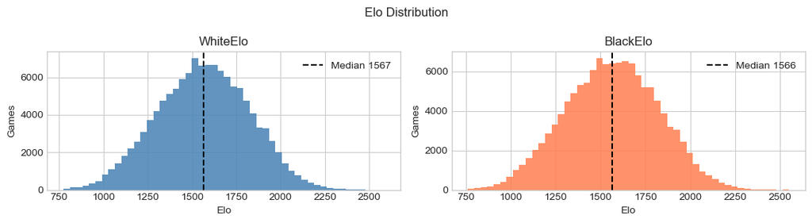

## 2 · Feature Engineering

We extract two groups of features that summarise a player's style without requiring real-time sequence processing at training time:

**Board features** (replayed via `chess_features_final.py`, ~30 columns): captures (density, first move, pawn vs piece), checks given, castling side/move, piece activity (consecutive same piece, queen before move 10), territory depth, and engine quality metrics (avg centipawn loss, blunders — NaN → 0 when evals absent).

**Clock features** (~10 columns): Average, std, max time spent per move; time pressure in the last 5 moves; opening pace in the first 5 moves. All normalised by the base time-control.

Both are cached to disk after the first run.

```
Board features loaded from cache  (35 cols)
Clock features loaded from cache  (10 cols)
```

```
Static features: 45
['acpl_black', 'acpl_white', 'b_avg_time_norm', 'b_max_time_norm', 'b_opening_pace', 'b_std_time_norm', 'b_time_pressure', 'black_territory_depth', 'blunder_count_black', 'blunder_count_white', 'blunder_density_black', 'blunder_density_white', 'capture_density', 'castle_move_black', 'castle_move_whi…
```

## 3 · Preprocessing

### Soft Elo targets

Rather than predicting a single number, we predict a **probability distribution** over 40 Elo bins. The target for a player with true rating *e* is a Gaussian with σ = 200 centred on *e*, normalised to sum to 1.

Training with **KL divergence** against this soft target naturally captures rating uncertainty — the model learns that 1400 and 1600 are close, not unrelated.

### Weighted sampling

Very low and very high Elo games are rare. **Inverse-frequency weighted sampling** oversamples these games during training so the model generalises across all skill levels.

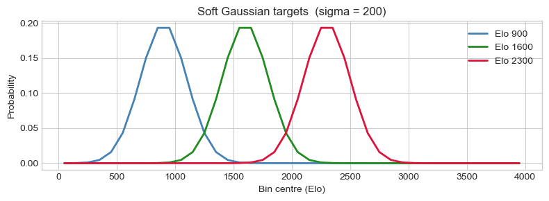

```
Train 99,886  val 12,486  test 12,486
Scaling applied (StandardScaler fit on train only)
```

```
Dropped 2,107 games shorter than 12 plies
Vocabulary: 7,644 distinct moves
```

```
Building datasets...
Built in 23s
Train batches per epoch: 768
```

```
============================================================
DATASET OVERVIEW
============================================================
  Train: 98,192  Val: 12,274  Test: 12,285
  Static feature dim : 45
  Sequence included  : True

============================================================
STATIC FEATURES  (sample game #0, before model)
============================================================
  tc_base                                  0.0000  ← NaN→0
  tc_inc                                  -0.2162
  total_ply_count                          2.5581
  material_balance_end                     0.9828
  result_encoded                           0.9783
  checks_given_white                       0.5298
  checks_given_black                       0.3502
  check_density_white                     -0.2343
  check_density_black                     -0.2754
  first_capture_move_white                -0.8048
  first_capture_move_black                -0.6110
  pawn_captures_total                      2.1155
  piece_captures_total                     1.4784
  capture_density                         -0.8131
  castle_move_white                        1.3675
  castle_move_black                       -1.1550
  consec_same_piece_white                  3.8974
  consec_same_piece_black                  3.9210
  queen_moves_before_10                   -0.2645
  white_territory_depth                    0.8285
  black_territory_depth                   -0.8986
  promotions                               1.5383
  en_passant_captures                     -0.1662
  legal_moves_white_move5                  0.0418
  legal_moves_black_move5                  1.3799
  acpl_white                              -0.2967
  inaccuracy_count_white                  -0.2870
  mistake_count_white                     -0.2782
  blunder_count_white                     -0.2533
  blunder_density_white                   -0.2628
  acpl_black                              -0.2954
  inaccuracy_count_black                  -0.2857
  mistake_count_black                     -0.2765
  blunder_count_black                     -0.2544
  blunder_density_black                   -0.2626
  w_avg_time_norm                         -1.1967
  w_std_time_norm                         -0.9061
  w_max_time_norm                         -0.5880
  w_time_pressure                         -0.8272
  w_opening_pace                          -0.7159
  b_avg_time_norm                         -1.0342
  b_std_time_norm                         -0.5281
  b_max_time_norm                         -0.2172
  b_time_pressure                         -0.9983
  b_opening_pace                          -0.6163

============================================================
ELO DISTRIBUTION TARGETS  (sample game #0)
============================================================
  White actual Elo : 1827   Black actual Elo : 1396
  White dist peak  : 1850   Black dist peak  : 1350
  White dist sum   : 1.0000  (should be 1.0)
```

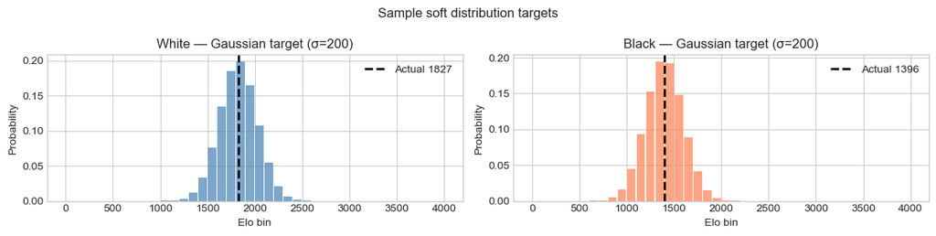

```
============================================================
MOVE SEQUENCE  (sample game #0)
============================================================
  Sequence length : 120 moves (capped at 120)

  Ply   Token ID   Move         Norm clock   Side
  ------------------------------------------------
  1     22         d4           2.000        White
  2     24         d5           2.000        Black
  3     217        e3           2.000        White
  4     5          Nc6          2.000        Black
  5     10         h3           2.000        White
  6     3          e5           2.000        Black
  7     287        dxe5         2.000        White
  8     576        Nxe5         2.000        Black
  9     4          Nf3          2.000        White
  10    236        Bd6          2.000        Black
  11    38         a3           2.000        White
  12    128        Be6          2.000        Black
  13    45         b4           2.000        White
  14    34         Nf6          2.000        Black
  15    235        Bb2          2.000        White
  16    5          Nc6          2.000        Black
  17    16         Bb5          2.000        White
  18    133        Qd7          2.000        Black
  19    141        Bxc6         2.000        White
  20    342        Qxc6         2.000        Black
  ... (100 more moves)
```

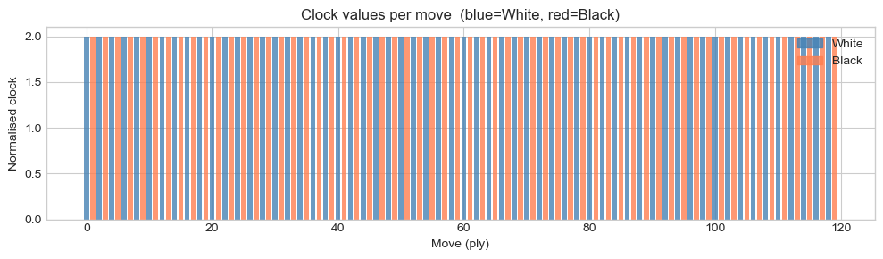

```
============================================================
ONE BATCH FROM train_loader
============================================================
  Keys in batch       : ['static', 'w_dist', 'b_dist', 'elos', 'moves', 'clocks', 'mask']
  static shape        : torch.Size([128, 45])   (batch_size × n_static_features)
  w_dist shape        : torch.Size([128, 40])   (batch_size × 40 bins)
  elos shape          : torch.Size([128, 2])     (batch_size × 2)
  moves shape         : torch.Size([128, 120])   (batch_size × padded_seq_len)
  clocks shape        : torch.Size([128, 120])
  mask shape          : torch.Size([128, 120])
  real tokens         : 8,588   padding tokens : 6,772
  avg sequence length : 67.1 moves in this batch

  Static feature stats across this batch:
  Feature                                  mean       std       min       max
  ------------------------------------------------------------------------
  tc_base                                 0.000     0.000     0.000     0.000
  tc_inc                                 -0.026     0.631    -0.216     3.065
  total_ply_count                         0.178     1.176    -1.610     4.383
  material_balance_end                   -0.109     1.051    -3.822     3.329
  result_encoded                         -0.151     0.995    -1.072     0.978
  checks_given_white                      0.059     1.185    -0.828     7.589
  checks_given_black                      0.041     1.056    -0.774     4.565
  check_density_white                    -0.048     0.945    -0.992     4.188
  check_density_black                     0.017     1.035    -0.923     3.611
  first_capture_move_white                0.011     0.968    -2.059     2.643
  ... (35 more features)
```

## 4 · Model Architectures

### Development history

**v1–v2 — BiLSTM baseline (MAE ≈ 200)**  
Initial model: two-layer BiLSTM over move sequences plus hand-crafted static features (captures, checks, castling, clock usage). Early experiments used a strict time-control filter (10 min only) that left just ~23 k games — too few to generalise. Relaxing to ≥ 3 min and scaling to 200 k → 1 M games brought MAE to ~200 Elo.

**v3 — Soft targets + KL divergence (MAE ≈ 185)**  
Switching from Huber regression to KL divergence over Gaussian soft targets improved calibration and reduced MAE by ~15 Elo. Inspired by Ouzounis et al. (2022).

**v4 — Clock features + 1 M games (MAE ≈ 165)**  
Adding per-move clock statistics (time pressure, opening pace) and training on 1 M games closed the gap further. A sequence autoencoder (BiLSTM → 32-d bottleneck) was also tested to pre-compute sequence embeddings for faster CPU training.

**This notebook — Four architectures compared**  
All models use the same data, features, loss, and training loop for a fair comparison.

### Model 1 · BiLSTM with soft attention

A two-layer **bidirectional LSTM** reads the move sequence and produces a hidden state at each position. **Soft attention** learns to weight these states, allowing the model to focus on the most informative moves.

- *Strength*: captures long-range move dependencies and is sensitive to move order.
- *Weakness*: sequential computation cannot be parallelised; can lose signal from early moves in long games.

### Model 2 · Residual MLP (features only)

A deep **residual MLP** over the static feature vector — no move sequences.

Each residual block applies `LayerNorm → Linear → GELU → Dropout → Linear` and adds the result back via a skip connection. Pre-norm residual connections train stably at depth and avoid gradient vanishing.

- *Strength*: fastest to train, no sequence overhead, very interpretable.
- *Weakness*: cannot see *which moves* were played, only aggregate statistics.

### Model 3 · Multi-scale 1D CNN

**Three parallel Conv1d branches** with kernel sizes 3, 5, and 7 capture move patterns at different scales: short tactics (k=3), medium plans (k=5), and longer strategic ideas (k=7). After convolution, **global max-pooling** picks the strongest filter activation across the whole game.

### Model 4 · Transformer Encoder

**Multi-head self-attention** lets every move attend to every other move in O(1), unlike LSTM which passes information through a chain of sequential states.

We use **sinusoidal positional encodings** (fixed, not learned) and **pre-norm layers** (LayerNorm before the attention/FFN blocks) which train more stably at depth. After encoding, we **mean-pool** over non-padding positions.

- *Strength*: direct connections between any pair of moves; highly parallelisable on GPU.
- *Weakness*: quadratic memory in sequence length; advantage over LSTM is less clear on short sequences (most games are ≤ 60 moves).

## 5 · Training

All models share the same training loop:

- **Loss**: KL divergence between log-softmax predictions and the Gaussian soft targets
- **Optimiser**: AdamW with cosine annealing (LR decays to 5% of initial)
- **Gradient clipping** at norm 1.0
- **Early stopping**: restores best weights if validation MAE does not improve for `PATIENCE` consecutive epochs

## 5a · Hyperparameter Optimisation (optional)

When `HPO_*` is enabled for a model, [Optuna](https://optuna.org/) runs a quick search before the full training. Each trial trains on a small subset (`HPO_GAMES`) for a few epochs (`HPO_EPOCHS`) and evaluates on the validation set.

The best parameters are cached to `checkpoints/hpo_*.pkl` — re-running the cell is instant if the cache exists (delete the file to force a fresh search).

If HPO is disabled, the default values from the config cell are used.

**Searched parameters:**

- *BiLSTM*: hidden dim, dropout
- *Residual MLP*: hidden dim, number of residual blocks, dropout
- *CNN*: filters per branch, embedding dim, dropout
- *Transformer*: d_model, attention heads, encoder layers, feedforward dim, dropout

```
BiLSTM HPO — 10 trials ...
```

```
BiLSTM best: {'hidden': 128, 'dropout': 0.1604508047660235}
Residual HPO — 10 trials ...
```

```
Residual best: {'hidden': 512, 'n_blocks': 8, 'dropout': 0.12371083025202256}
CNN HPO — 10 trials ...
```

```
CNN best: {'n_filters': 128, 'embed_dim': 128, 'dropout': 0.3012060387480253}
Transformer HPO — 10 trials ...
```

```
Transformer best: {'n_heads': 4, 'd_model': 128, 'n_layers': 2, 'ff_dim': 512, 'dropout': 0.27312652867187337}

Final params:
  BiLSTM      : {'hidden': 128, 'dropout': 0.1604508047660235}
  Residual MLP: {'hidden': 512, 'n_blocks': 8, 'dropout': 0.12371083025202256}
  CNN         : {'n_filters': 128, 'embed_dim': 128, 'dropout': 0.3012060387480253}
  Transformer : {'n_heads': 4, 'd_model': 128, 'n_layers': 2, 'ff_dim': 512, 'dropout': 0.27312652867187337}
```

```
Training BiLSTM
----------------------------------------
   1/10  loss=1.1382  val_mae=178.1
   2/10  loss=0.7616  val_mae=169.1
   3/10  loss=0.6645  val_mae=161.8
   4/10  loss=0.6017  val_mae=169.6
   5/10  loss=0.5667  val_mae=164.1
   6/10  loss=0.5370  val_mae=156.6
   7/10  loss=0.5108  val_mae=156.7
   8/10  loss=0.4939  val_mae=157.0
   9/10  loss=0.4828  val_mae=158.4
  Early stop at epoch 9
  Test MAE: 156.7

Training Residual MLP
----------------------------------------
   1/10  loss=0.9771  val_mae=197.0
   2/10  loss=0.8003  val_mae=192.9
   3/10  loss=0.7097  val_mae=192.3
   4/10  loss=0.6381  val_mae=191.8
   5/10  loss=0.5717  val_mae=196.4
   6/10  loss=0.5180  val_mae=191.6
   7/10  loss=0.4617  val_mae=185.0
   8/10  loss=0.4216  val_mae=189.9
   9/10  loss=0.3925  val_mae=187.7
  10/10  loss=0.3703  val_mae=188.6
  Early stop at epoch 10
  Test MAE: 184.6

Training CNN
----------------------------------------
   1/10  loss=0.9360  val_mae=158.4
   2/10  loss=0.5073  val_mae=178.7
   3/10  loss=0.4109  val_mae=159.2
   4/10  loss=0.3466  val_mae=165.1
  Early stop at epoch 4
  Test MAE: 158.1

Training Transformer
----------------------------------------
   1/10  loss=1.1479  val_mae=179.1
   2/10  loss=0.8042  val_mae=166.9
   3/10  loss=0.7094  val_mae=184.5
   4/10  loss=0.6598  val_mae=167.4
   5/10  loss=0.6161  val_mae=168.2
  Early stop at epoch 5
  Test MAE: 165.8
```

## 6 · Results & Comparison

```
             White MAE Black MAE Combined MAE Within 100 Within 200 Within 300
Model
BiLSTM           156.7     156.6        156.7      26.2%      59.3%      81.3%
Residual MLP     184.6     184.6        184.6      20.7%      50.9%      73.4%
CNN              158.4     157.8        158.1      26.2%      58.1%      80.8%
Transformer      164.9     166.8        165.8      25.1%      57.4%      78.8%
```

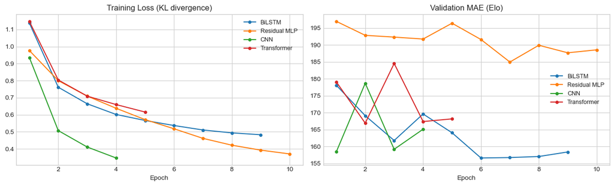

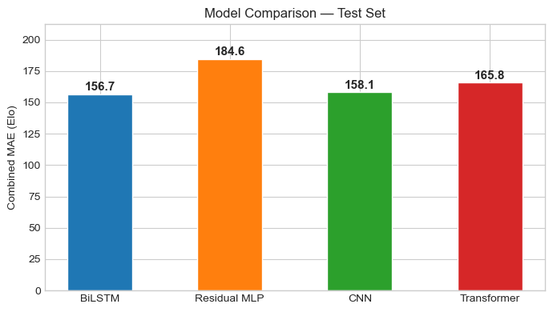

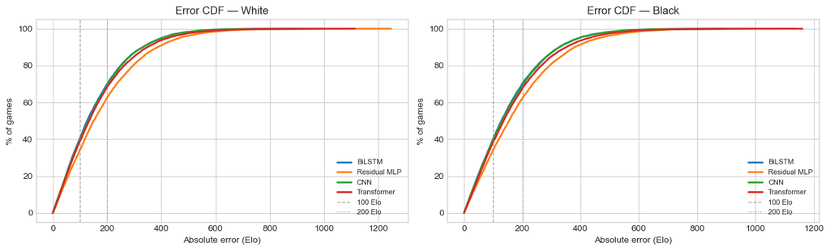

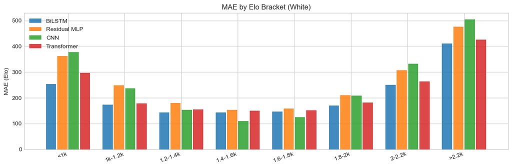

```
=================================================================
FEATURE IMPORTANCE — all models
=================================================================

  Computing for BiLSTM...
    Base MAE: 156.3

  Computing for Residual MLP...
    Base MAE: 185.4

  Computing for CNN...
    Base MAE: 157.9

  Computing for Transformer...
    Base MAE: 164.9

=================================================================
DELTA MAE  (positive = removing this hurts the model)
=================================================================
  Feature / Branch                         BiLSTM   Residual MLP            CNN    Transformer
  --------------------------------------------------------------------------------------------
  static: game_structure                      4.3           24.4            1.8            6.4
  static: checks                              0.6            2.4            0.9            1.1
  static: captures                            0.7            6.9            2.2            1.4
  static: castling                            0.2            1.6           -0.3           -0.1
  static: style                               8.6           25.1            4.7           15.7
  static: engine_quality                      3.9            6.6           -0.3            4.8
  static: clock                               3.8           11.5            6.9            5.6
  static: tc_meta                             0.9            4.4            0.3            1.7
  [remove sequence]                         215.6              —           49.9          147.1
  [remove static]                            42.0              —           12.9           33.1
  seq phase: Early (1-15)                    16.1              —           17.6           36.6
  seq phase: Mid (1-30)                       1.3              —            1.5            8.4
  --------------------------------------------------------------------------------------------
  Base MAE                                  156.3          185.4          157.9          164.9
```

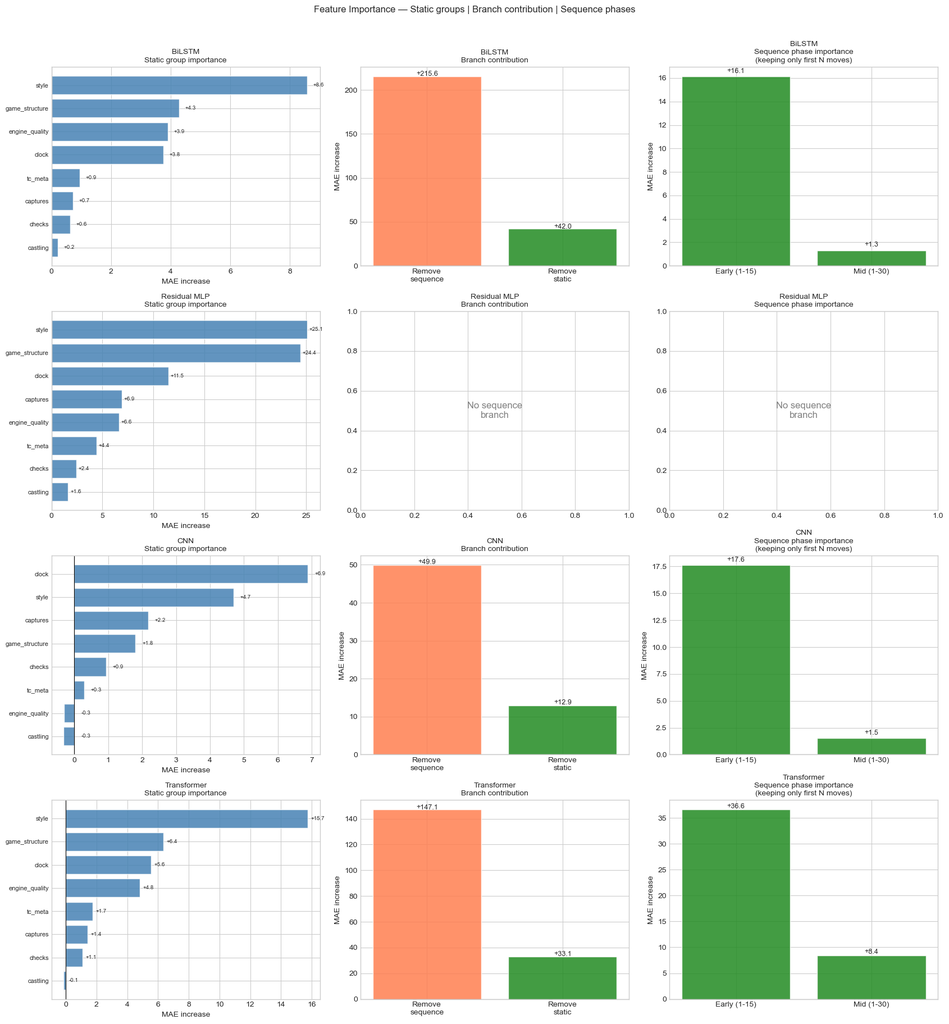

```
SUMMARY
-------------------------------------------------------

  BiLSTM  (base MAE = 156.3)
    Most important static group : style  (Δ=+8.6)
    Removing sequence adds      : +215.6 Elo
    Removing static adds        : +42.0 Elo
    Dominant branch             : sequence

  Residual MLP  (base MAE = 185.4)
    Most important static group : style  (Δ=+25.1)

  CNN  (base MAE = 157.9)
    Most important static group : clock  (Δ=+6.9)
    Removing sequence adds      : +49.9 Elo
    Removing static adds        : +12.9 Elo
    Dominant branch             : sequence

  Transformer  (base MAE = 164.9)
    Most important static group : style  (Δ=+15.7)
    Removing sequence adds      : +147.1 Elo
    Removing static adds        : +33.1 Elo
    Dominant branch             : sequence
```

## 7 · Ensemble

When multiple models are trained, we average their **predicted distributions** (not just the point estimates). Because each model's errors are partially independent, ensemble averaging typically improves both accuracy and calibration.

```
Ensemble combined MAE: 149.5  (White 149.4, Black 149.6)
```

```
==================================================
             Combined MAE Within 100 Within 200 Within 300
Model
BiLSTM              156.7      26.2%      59.3%      81.3%
Residual MLP        184.6      20.7%      50.9%      73.4%
CNN                 158.1      26.2%      58.1%      80.8%
Transformer         165.8      25.1%      57.4%      78.8%
Ensemble            149.5      27.2%      61.6%      83.0%
==================================================
Best single model: BiLSTM  (MAE = 156.7)
```

## 8 · Single Game Demo

Paste any PGN string below and run the cell to predict both players' Elo ratings using every trained model.

```
Model                White Elo   Black Elo
--------------------------------------------
  BiLSTM                  1818        1804
  Residual MLP            1833        1736
  CNN                     1734        1739
  Transformer             1784        1788
```